# Parallel Processing with terra and SNIC

Large rasters often need to be processed before the segmentation (normalizing bands, computing indices, masking clouds). `terra` offers chunk-wise processing with optional parallel execution via `terra::app()`. This vignette benchmarks those options on the Sentinel-2 subset bundled with the package and feeds the processed cube into `snic()`.

## Preparing the scene

```r
data_dir <- system.file("S2-20LMR", package = "snic", mustWork = TRUE)
bands <- file.path(
  data_dir,
  c(
    "S2_20LMR_B02_20220630.tif",
    "S2_20LMR_B04_20220630.tif",
    "S2_20LMR_B08_20220630.tif",
    "S2_20LMR_B12_20220630.tif"
  )
)
s2 <- rast(bands)
s2_demo <- aggregate(s2, fact = 8)
```

The reduced tile keeps multi-band structure while running quickly enough for vignette examples.

## Chunk-wise normalization

The function below scales each band to zero mean and unit variance while avoiding division by zero.

```r
normalize <- function(x) {
  s <- sd(x, na.rm = TRUE)
  if (is.na(s) || s == 0) {
    return(rep(0, length(x)))
  }
  (x - mean(x, na.rm = TRUE)) / s
}
```

`terra::app()` processes data in blocks that fit into memory. Setting `cores > 1` spins up a `PSOCK` cluster to work on multiple chunks simultaneously. Some environments (including vignette builders) may restrict opening network sockets, so the example guards against failures and falls back to serial execution.

```r
terraOptions(progress = 0)

single_core <- system.time({
  demo_single <- terra::app(s2_demo, normalize, cores = 1)
})

multi_core <- tryCatch({
  system.time({
    demo_multi <- terra::app(s2_demo, normalize, cores = 2)
  })
}, error = function(e) {
  message("Skipping multi-core example: ", conditionMessage(e))
  single_core * NA_real_
})

if (exists("demo_single")) rm(demo_single)
if (exists("demo_multi")) rm(demo_multi)

rbind(
  single_core = single_core,
  multi_core = multi_core
)[, c("user.self", "elapsed")]
```

```
#>             user.self elapsed
#> single_core     0.121   0.132
#> multi_core      0.148   3.028
```

On larger rasters the difference between single and multi-core runs becomes more pronounced, especially when the worker processes are allowed to write temporary files locally.

## Feeding the processed cube into SNIC

```r
s2_scaled <- tryCatch(
  app(s2_demo, normalize, cores = 2),
  error = function(e) {
    message("Falling back to single-core scaling: ", conditionMessage(e))
    app(s2_demo, normalize, cores = 1)
  }
)

spacing <- 30L
seeds <- snic_grid_rect(s2_scaled, spacing = spacing)
seg <- snic(s2_scaled, seeds = seeds, compactness = 0.6)
```

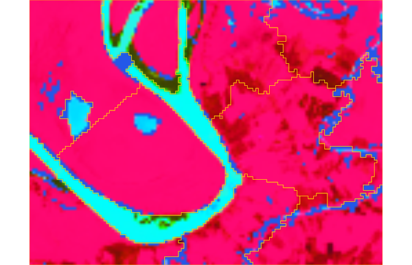

```r
snic_plot(
  s2_scaled,
  r = 3, g = 2, b = 1,
  stretch = "lin",
  seg = seg,
  seg_plot_args = list(border = "#FFD700", col = NA, lwd = 0.6)
)
```

The combination of chunk-wise computations and carefully chosen seeds ensures that processing scales to large rasters while leaving the segmentation step reproducible and efficient.

## Tips for larger workloads

- Use `terraOptions(memfrac = ...)` to keep RAM usage under control.
- Prefer writing temporary outputs to a fast local disk (`terraOptions(tempdir = "path")`).
- Persist frequently reused derivatives (e.g. indices) to disk so they can be reused across segmentation runs.
- When running on clusters, configure `future` or `foreach` to parallelize across tiles and keep `terra::app()` within each tile serial to avoid nested clusters.